# Wine analysis

# Objetive:

## Create a model to estimate the wine quality.

## Original Problem Description:

1. The problem:
- The present problem refers to the data of portuguese wines “Vinho Verde” (Green Wine), which have white and red variants. Due to privacy issues, only the physical-chemical (input) and sensory (output) variables are available ( for instance, there is no data about which kind of grape, brand of wine, price of sale, etc).
2. Sources
- Created by: Paulo Cortez (Univ. Minho), Antonio Cerdeira, Fernando Almeida, Telmo Matos and Jose Reis (CVRVV) @ 2009
3. Past Usage:
- P. Cortez, A. Cerdeira, F. Almeida, T. Matos and J. Reis.
- Modeling wine preferences by data mining from physicochemical properties.
- In Decision Support Systems, Elsevier, 47(4):547-553. ISSN: 0167-9236.
- In the above reference, two datasets were created, using red and white wine samples.
- The inputs include objective tests (e.g. PH values) and the output is based on sensory data (median of at least 3 evaluations made by wine experts). Each expert graded the wine quality between 0 (very bad) and 10 (very excellent). Several data mining methods were applied to model these datasets under a regression approach. The support vector machine model achieved the best results. Several metrics were computed: MAD, confusion matrix for a fixed error tolerance (T), etc. Also, we plot the relative importances of the input variables (as measured by a sensitivity analysis procedure).
4. Relevant Information:
- The two datasets are related to red and white variants of the Portuguese “Vinho Verde” wine.
- For more details, consult: http://www.vinhoverde.pt/en/ or the reference [Cortez et al., 2009](https://www.sciencedirect.com/science/article/pii/S0167923609001377?via%3Dihub).
- Due to privacy and logistic issues, only physicochemical (inputs) and sensory (the output) variables are available (e.g. there is no data about grape types, wine brand, wine selling price, etc.).
- These datasets can be viewed as classification or regression tasks.
- The classes are ordered and not balanced (e.g. there are munch more normal wines than excellent or poor ones). Outlier detection algorithms could be used to detect the few excellent or poor wines. Also, we are not sure if all input variables are relevant. So it could be interesting to test feature selection methods.
5. Number of Instances: red wine - 1599; white wine - 4898.
6. Number of Attributes: 11 + output attribute
- Note: several of the attributes may be correlated, thus it makes sense to apply some sort of feature selection.
- For more information, read [Cortez et al., 2009](https://www.sciencedirect.com/science/article/pii/S0167923609001377?via%3Dihub).

*Input* variables (based on physicochemical tests):

7. Attribute information:
- fixed acidity
- volatile acidity
- citric acid
- residual sugar
- chlorides
- free sulfur dioxide
- total sulfur dioxide
- density
- pH
- sulphates
- alcohol

*Output* variable (based on sensory data):

- Quality (score between 0 and 10)
8. Missing Attribute Values: None

## Quick literature review

First step taken is to do a quick bibliography review about the subject in order to reproduce previously conducted research and improve upon it.

## Google Search

### First Review

at “30/11/2018 21:00 GMT -3, daylight saving” :

- All input variables were added to the search, which returned one match to this [link](https://pubag.nal.usda.gov/pubag/downloadPDF.xhtml?id=27220&content=PDF). This paper provides a description of the effect of physical-chemical properties of tomatoes on its flavour.
- The words ‘wine quality analysis portuguese “Vinho Verde”’ were pre-appended to the previously search and the first hit provided this link which lead to the reference at this [link](https://www.sciencedirect.com/science/article/pii/S0167923609001377?via%3Dihub) and the original dataset [here](https://archive.ics.uci.edu/ml/machine-learning-databases/wine-quality/).
- The above paper was not publicly available. A search for the name of the paper (*Modeling wine preferences by data mining from physicochemical properties*) resulted on a similar public paper at this [link](http://www.scitepress.org/Papers/2015/55519/55519.pdf).
- This paper titled ‘Modeling Wine Preferences from Physicochemical Properties using Fuzzy techniques’ contains a comparison of several models of the same dataset and therefore were selected for a detailed analysis the review.
- Other results for “Modeling wine preferences by data mining fromphysicochemical properties. In Decision SupportSystems arxiv” were saved for a second take on bibliography review.

## Download exercice Data:

```r
library(data.table)

url='https://drive.google.com/uc?auth_user=0&id=1-oG5-kBt9xQ3Li4PEexpiA9_7RZhRM1f&export=download'
temp <- tempfile(fileext = ".csv")
download.file(url,temp)
wine <- fread(temp, sep = ";", encoding = 'UTF-8')
print(wine[,lapply(.SD,class),type])
```

```
##     type fixed acidity volatile acidity citric acid residual sugar
## 1: White       numeric          numeric     numeric        numeric
## 2:   Red       numeric          numeric     numeric        numeric
##    chlorides free sulfur dioxide total sulfur dioxide density      pH
## 1:   numeric             numeric              numeric numeric numeric
## 2:   numeric             numeric              numeric numeric numeric
##    sulphates   alcohol quality
## 1:   numeric character integer
## 2:   numeric character integer
```

It is strange that the alcohol is classified as character.

```r
names(table(wine[type=="White"]$alcohol)[1:20])
```

```
##  [1] "10"                  "10.1"                "10.15"
##  [4] "10.2"                "10.3"                "10.4"
##  [7] "10.5"                "10.55"               "10.6"
## [10] "10.65"               "10.7"                "10.8"
## [13] "10.9"                "10.98"               "100.333.333.333.333"
## [16] "101.333.333.333.333" "104.666.666.666.667" "105.333.333.333.333"
## [19] "105.666.666.666.667" "109.333.333.333.333"
```

## The data seems to be corrupted. The original dataset looks like:

```r
library(data.table)
url='https://archive.ics.uci.edu/ml/machine-learning-databases/wine-quality/winequality-white.csv'
#temp <- tempfile(fileext = ".csv")
temp='data/winequality-white.csv'
if(!file.exists(temp)){
  download.file(url, temp)
}
wine_or <- fread(temp, sep = ";", encoding = 'UTF-8')
url='https://archive.ics.uci.edu/ml/machine-learning-databases/wine-quality/winequality-red.csv'
temp='data/winequality-red.csv'
if(!file.exists(temp)){
  download.file(url, temp)
}
wine_red <- fread(temp, sep = ";", encoding = 'UTF-8')
wine_or$type="White"
wine_red$type="Red"
wine=rbind(wine_or,wine_red)
print(wine[,lapply(.SD,class),])
```

```
##    fixed acidity volatile acidity citric acid residual sugar chlorides
## 1:       numeric          numeric     numeric        numeric   numeric
##    free sulfur dioxide total sulfur dioxide density      pH sulphates
## 1:             numeric              numeric numeric numeric   numeric
##    alcohol quality      type
## 1: numeric integer character
```

The alcohol levels must be between 8 and 15:

```r
a=as.numeric(gsub("\\.","",wine$alcohol))
a=a/10^floor(log(a)/log(10))
a[a<5]=a[a<5]*10
wine$alcohol=a
sum(wine[type=="White"]$alcohol-wine_or$alcohol)
```

```
## [1] 1.936229e-13
```

The assumption was correct, after ajusting the data the difference is really small, we should use the original data to avoid these errors.

## Wine alcohol distribuition

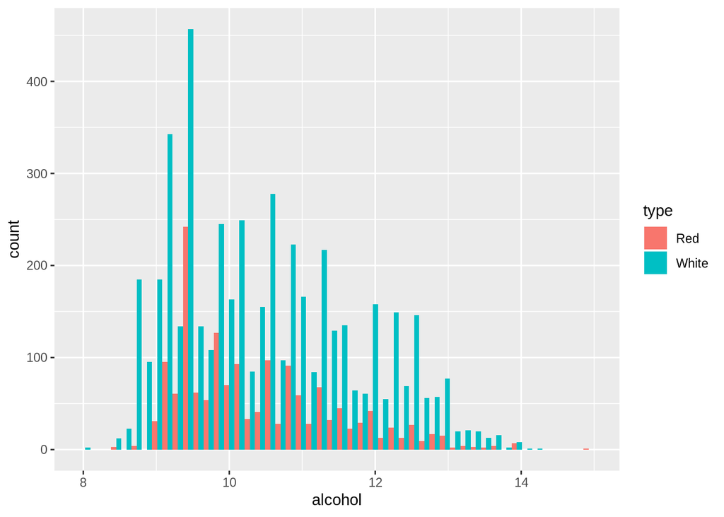

```r
library(ggplot2)
ggplot(wine,aes(x=alcohol,fill=type))+geom_histogram(position = 'dodge',bins=50)
```

Let’s see if the data from the paper matches the one at hand. Let’s compare both summary data:

Paper’s:

[figure not shown]

Fuzzy

```r
(t(wine[,lapply(.SD,function(s){list(min(s),max(s),mean(s))}),type]))
```

```
##                      [,1]    [,2]    [,3]       [,4]    [,5]    [,6]
## type                 "White" "White" "White"    "Red"   "Red"   "Red"
## fixed acidity        3.8     14.2    6.854788   4.6     15.9    8.319637
## volatile acidity     0.08    1.1     0.2782411  0.12    1.58    0.5278205
## citric acid          0       1.66    0.3341915  0       1       0.2709756
## residual sugar       0.6     65.8    6.391415   0.9     15.5    2.538806
## chlorides            0.009   0.346   0.04577236 0.012   0.611   0.08746654
## free sulfur dioxide  2       289     35.30808   1       72      15.87492
## total sulfur dioxide 9       440     138.3607   6       289     46.46779
## density              0.98711 1.03898 0.9940274  0.99007 1.00369 0.9967467
## pH                   2.72    3.82    3.188267   2.74    4.01    3.311113
## sulphates            0.22    1.08    0.4898469  0.33    2       0.6581488
## alcohol              8       14.2    10.51427   8.4     14.9    10.42298
## quality              3       9       5.877909   3       8       5.636023
```

Before trying to reproduce a complex model like FIR. Let’s see the properties of our input data to see if there is a simpler model we can try first.

### Are our input data Normal?

Applying the ad.test(x) to all input variables. If the p.value is below 0.05/12, we reject the normality hypothesis for all variables.

```r
library(nortest)
vars=wine[,lapply(.SD, function(s) ad.test(s)$p.value),.SDcols = setdiff(colnames(wine),c("Quality","type")), type]
mvars=melt(vars,id.vars='type')
mvars$value=unlist(mvars$value)
mvars=mvars[,.(pvalue=sum(value)),type]
mvars
```

| type | pvalue |
| --- | --- |
| White | 4.440000e-23 |
| Red | 9.245331e-05 |

It is a strong case for deviation from normality, let’s perform a visual inspection on centered and scaled variables

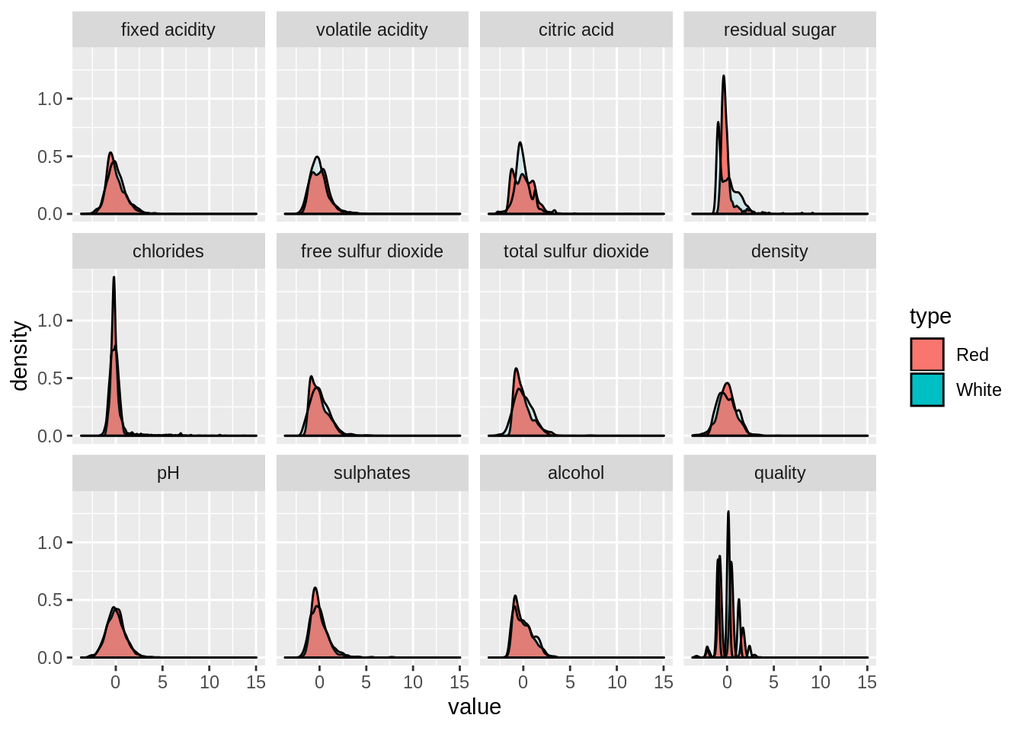

```r
library(ggplot2)
mwine=melt(wine,id.vars='type')
mwine[,value:=scale(value),.(type,variable)]
ggplot(mwine,aes(x=value,fill=type,alpha=ifelse(type=="White",0.5,0.6)))+geom_density()+facet_wrap(~variable)+guides(alpha=F)
```

They are somewhat normal like with long tails and high positive skewness, but some variables have a larger deviation from normality. A closer Inspection may be due for the residual sugar, citric acid and quality.

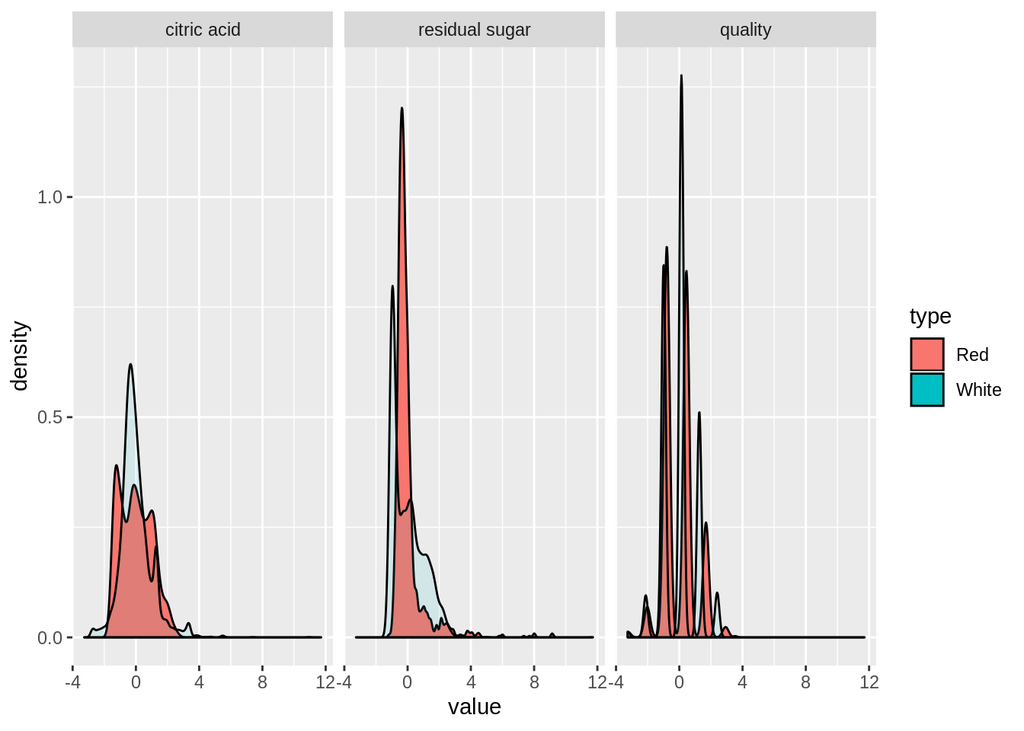

```r
ggplot(mwine[variable %in% c('citric acid', 'residual sugar', 'quality')],aes(x=value,fill=type,alpha=ifelse(type=="White",0.5,0.6)))+geom_density()+facet_wrap(~variable)+guides(alpha=F)
```

The input data may be multi model,

## Bivariate analysis

### What is the correlation between the variables?

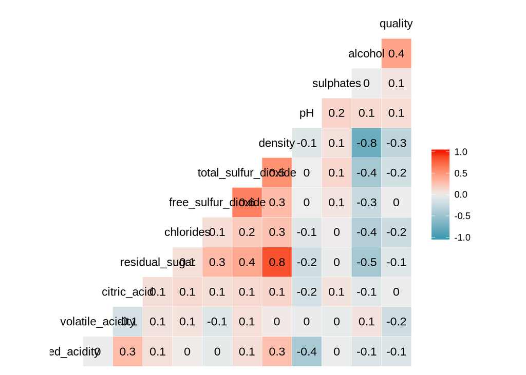

```r
library(GGally)
m=cbind(wine[type=="White",1:11],scale(wine[type=="White"]$quality))
names(m)[12]="quality"
dm=cor(m)
ggcorr(m,label=T)
```

## How can we group similar inputs?

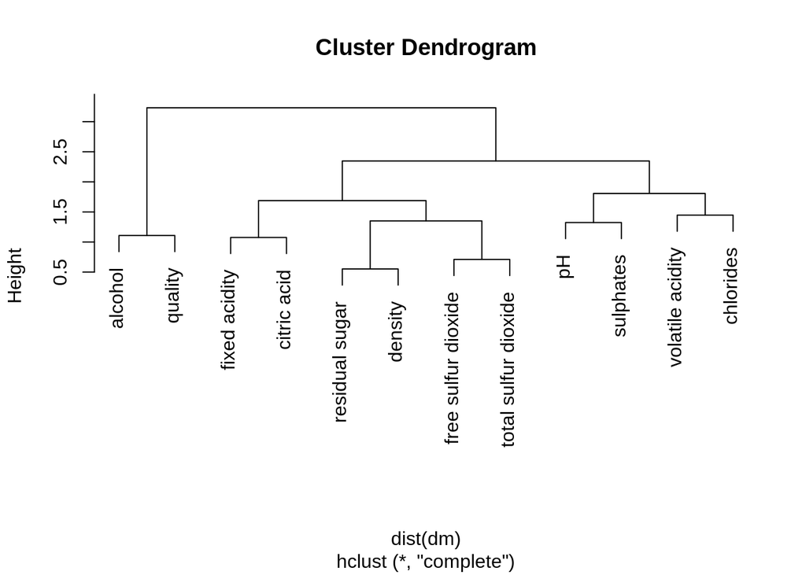

```r
plot(hclust(dist(dm)))
```

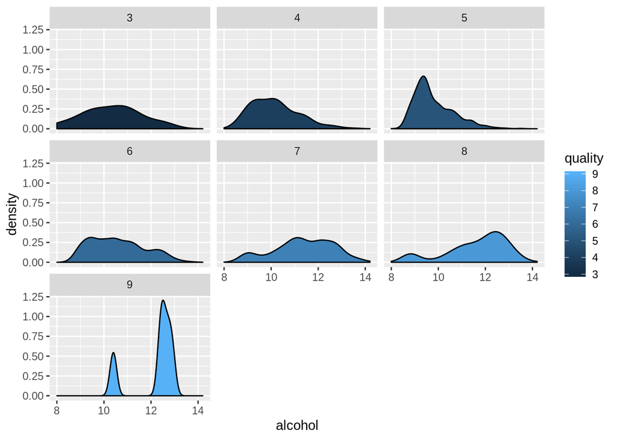

```r
ggplot(wine[type=="White",],aes(x=alcohol,fill=quality))+geom_density()+facet_wrap(~quality)
```

For high quality wines the alcohol levels are pretty high.

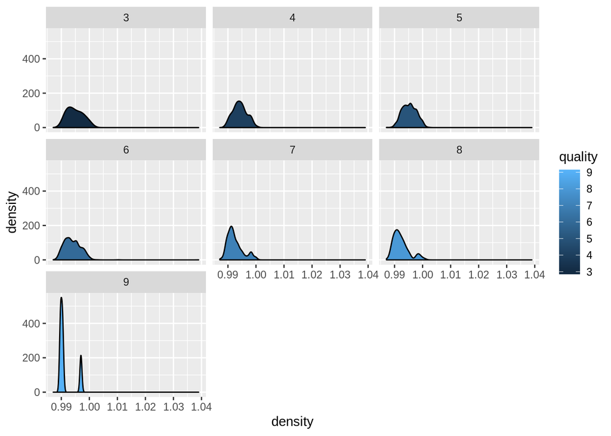

```r
ggplot(wine[type=="White",],aes(x=density,fill=quality))+geom_density()+facet_wrap(~quality)
```

The density correlation with quality may be indirect due to the high density x alcohol correlation.

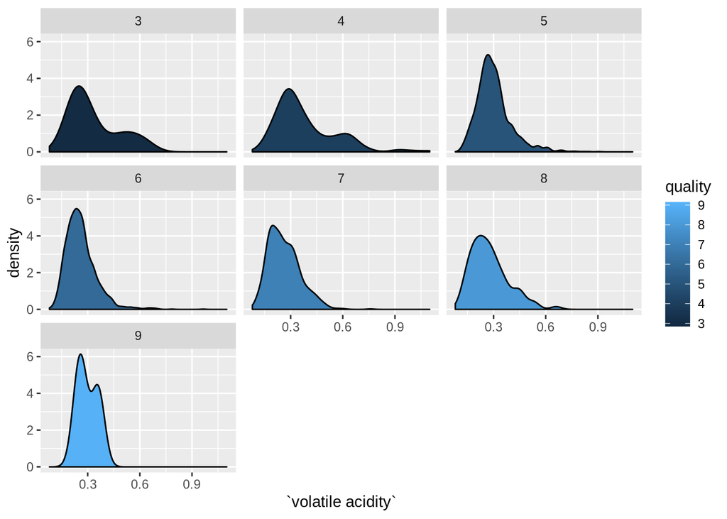

```r
ggplot(wine[type=="White",],aes(x=`volatile acidity`,fill=quality))+geom_density()+facet_wrap(~quality)
```

Low quality wines white have a higher volatile acidity.

### Remove colinearity with principal components analysis

```r
r=prcomp(wine[type=="White",1:11],scale=T)
((r$sdev^2/sum(r$sdev^2)))
```

```
##  [1] 0.29293217 0.14320363 0.11106103 0.09259294 0.08848496 0.08534014
##  [7] 0.06605437 0.05448713 0.03764942 0.02631701 0.00187719
```

# define importance by the order of the correlation of the components with the target variable

```r
components=predict(r,newdata=wine[type=="White",1:11])
correlation=cor(components,wine[type=="White", "quality"])
importance=as.data.table(correlation,keep.rownames = T)[order(-abs(quality))]
importance
```

| rn | quality |
| --- | --- |
| PC1 | -0.296947479 |
| PC9 | -0.259893930 |
| PC3 | -0.218263821 |
| PC4 | 0.190743712 |
| PC8 | -0.160063840 |
| PC11 | -0.077929519 |
| PC10 | 0.066071238 |
| PC2 | 0.058115768 |
| PC5 | -0.047130559 |
| PC7 | -0.021256182 |

[output cut: 1 more lines]

# A quick analysis of variance let us discard components not significant to the regression

```r
pcdata=data.table(components[,importance$rn])
pcdata$group = as.double(wine[type=="White"]$quality)
summary(aov(group ~ .,data=pcdata))
```

```
##               Df Sum Sq Mean Sq F value   Pr(>F)
## PC1            1  338.7   338.7 599.943  < 2e-16 ***
## PC9            1  259.4   259.4 459.561  < 2e-16 ***
## PC3            1  183.0   183.0 324.126  < 2e-16 ***
## PC4            1  139.7   139.7 247.543  < 2e-16 ***
## PC8            1   98.4    98.4 174.316  < 2e-16 ***
## PC11           1   23.3    23.3  41.319 1.42e-10 ***
## PC10           1   16.8    16.8  29.701 5.29e-08 ***
## PC2            1   13.0    13.0  22.979 1.69e-06 ***
## PC5            1    8.5     8.5  15.113 0.000103 ***
## PC7            1    1.7     1.7   3.074 0.079610 .
## PC6            1    0.1     0.1   0.109 0.741177
## Residuals   4886 2758.3     0.6
## ---
## Signif. codes:  0 '***' 0.001 '**' 0.01 '*' 0.05 '.' 0.1 ' ' 1
```

A cross validated regression would soften the impact of outliers in the dataset

```r
source("fit.R")
results=myfit(pcdata[,-c("PC7","PC6")], 'lm')
(results$train)
```

```
## Linear Regression
##
## 4898 samples
##    9 predictor
##
## No pre-processing
## Resampling: Cross-Validated (5 fold, repeated 20 times)
## Summary of sample sizes: 3918, 3919, 3918, 3919, 3918, 3918, ...
## Resampling results:
##
##   RMSE       Rsquared  MAE
##   0.7537895  0.276386  0.5852409
##
## Tuning parameter 'intercept' was held constant at a value of TRUE
```

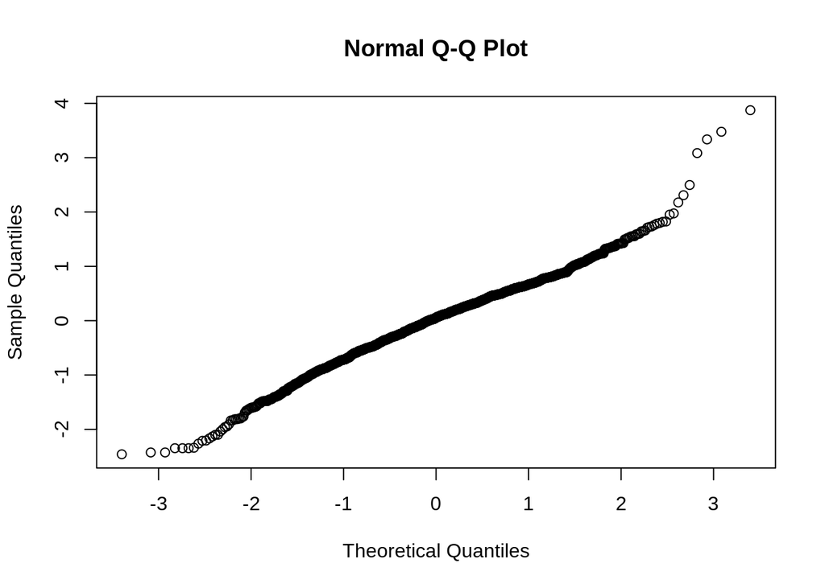

```r
qqnorm(results$test-results$testdata$group)
```

```r
mad=list()
mad$test=sum(abs(results$test-results$testdata$group))/length(results$test)
mad$train.mae=results$train$results$MAE
mad$train.mae.sd=results$train$results$MAESD
mad
```

```
## $test
## [1] 0.578001
##
## $train.mae
## [1] 0.5852409
##
## $train.mae.sd
## [1] 0.01043434
```

The results are compatible with the Multiple Regression present at [Modeling Wine Preferences from Physicochemical Properties using Fuzzy inductive reasoning](http://www.scitepress.org/Papers/2015/55519/55519.pdf) and are within expected values for performance within the trained set, e. g. it have not been overfitted.

## How different are the means of each input compared to the quality?

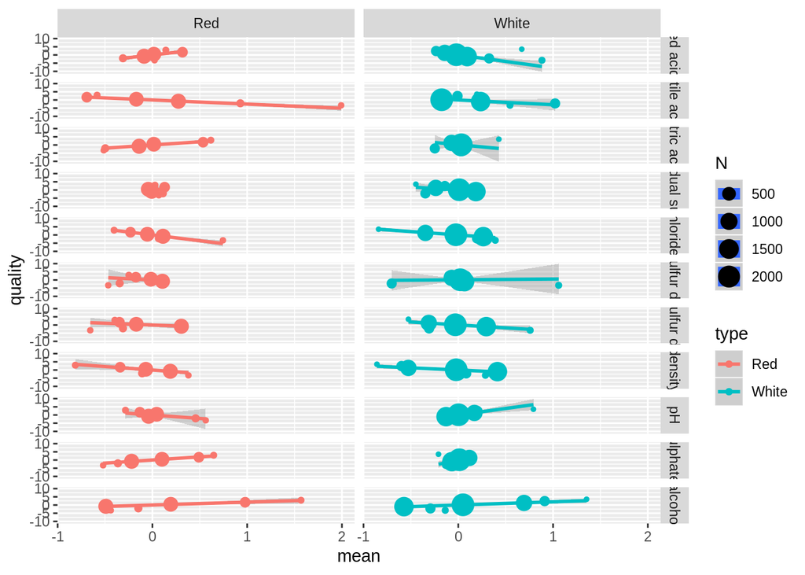

```r
q=mwine[variable=="quality"]$value
qmwine=mwine[variable!="quality"]
qmwine$quality=q
qmwine=qmwine[,.(mean=mean(value), sm =sd(value),N=.N),.(variable,type,quality)]
ggplot(qmwine[order(quality,type,variable)],aes(x=mean,y=quality,color=type,size=N,weight=N/sm))+
  geom_smooth(method="lm",se=T)+geom_point()+facet_grid(variable~type)
```

# Leverage

The top two grades also deviates, but differently

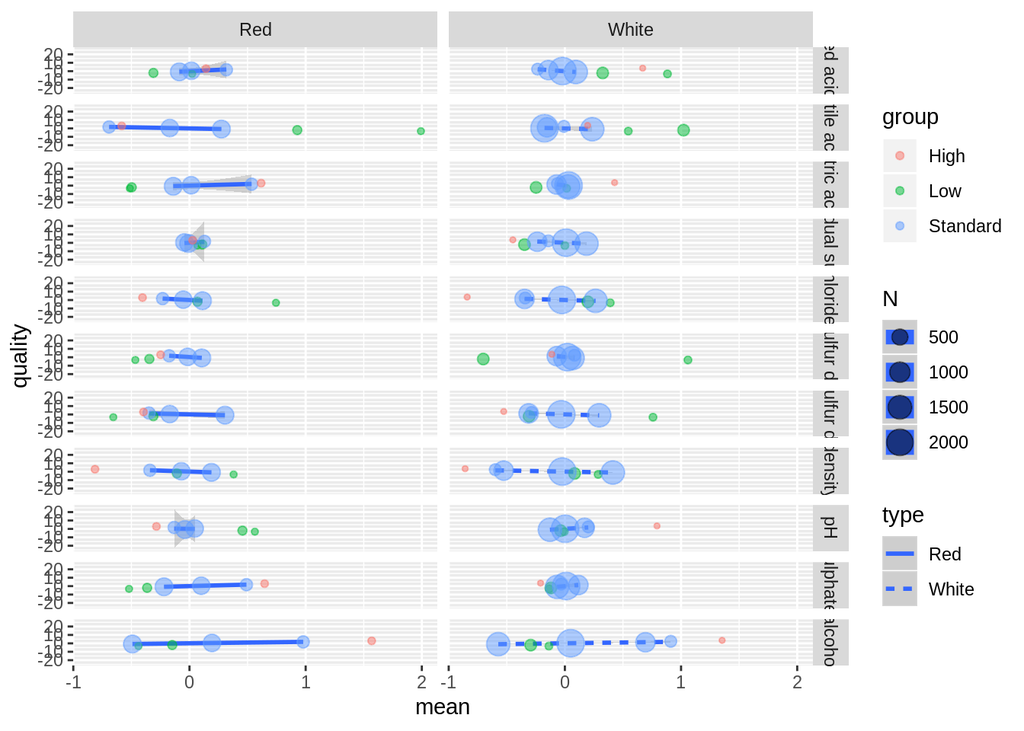

```r
qmwine$group = "Standard"
qmwine[quality< -2]$group = "Low"
qmwine[quality > 2.5]$group = "High"

ggplot(qmwine[order(quality,type,variable)],aes(x=mean,y=quality,size=N,weight=N/sm))+
  geom_smooth(data=qmwine[group=="Standard"],method="lm",se=T,aes(linetype=type,group=group))+geom_point(aes(color=group),alpha=0.5)+facet_grid(variable~type)
```

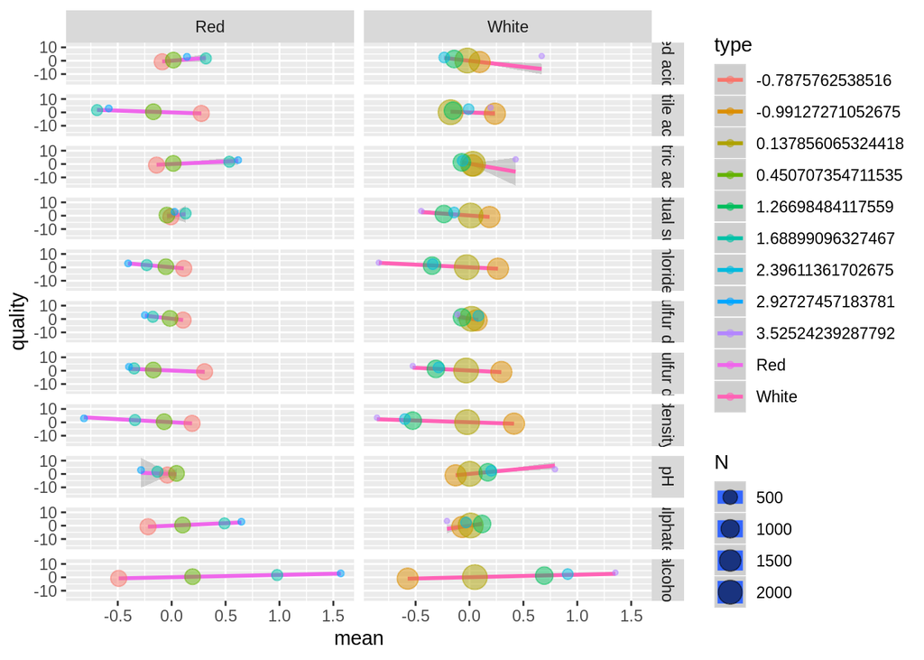

```r
ggplot(qmwine[order(quality,type,variable)][quality>-2],aes(x=mean,y=quality,size=N,weight=N/sm))+
  geom_smooth(method="lm",se=T,aes(color=type))+geom_point(aes(color=factor(quality)),alpha=0.5)+facet_grid(variable~type)
```

### LDA classification and regression

```r
quality=c("Lowest", "Low", "MediumLow","Medium","MediumHigh","High" ,"Highest")
source("fit.R")
classdata=pcdata[,-c("PC7","PC6")]
classdata$group=factor(quality[classdata$group-2]
                       , levels=quality, ordered=T)
ldafit=myfit(classdata,'lda')
#predicted=data.table(predict(ldafit$train,newdata = ldafit$testdata,type="prob"))

caret::confusionMatrix(ldafit$train)
```

```
## Cross-Validated (5 fold, repeated 20 times) Confusion Matrix
##
## (entries are percentual average cell counts across resamples)
##
##             Reference
## Prediction   Lowest  Low MediumLow Medium MediumHigh High Highest
##   Lowest        0.0  0.0       0.0    0.0        0.0  0.0     0.0
##   Low           0.0  0.7       0.9    0.4        0.0  0.0     0.0
##   MediumLow     0.1  1.4      14.8    8.0        0.9  0.1     0.0
##   Medium        0.2  1.2      13.9   32.7       12.1  2.2     0.0
##   MediumHigh    0.0  0.1       0.2    3.8        5.0  1.3     0.1
##   High          0.0  0.0       0.0    0.0        0.0  0.0     0.0
##   Highest       0.0  0.0       0.0    0.0        0.0  0.0     0.0
##
##  Accuracy (average) : 0.5318
```

```r
caret::confusionMatrix(table(ldafit$test,ldafit$testdata$group)/dim(ldafit$testdata)[1])
```

```
## Confusion Matrix and Statistics
##
##
##                    Lowest          Low    MediumLow       Medium
##   Lowest     0.0006793478 0.0000000000 0.0000000000 0.0000000000
##   Low        0.0000000000 0.0067934783 0.0088315217 0.0047554348
##   MediumLow  0.0006793478 0.0101902174 0.1474184783 0.0822010870
##   Medium     0.0027173913 0.0156250000 0.1365489130 0.3233695652
##   MediumHigh 0.0000000000 0.0006793478 0.0047554348 0.0380434783
##   High       0.0000000000 0.0000000000 0.0000000000 0.0000000000
##   Highest    0.0000000000 0.0000000000 0.0000000000 0.0000000000
##
##                MediumHigh         High      Highest
##   Lowest     0.0000000000 0.0000000000 0.0000000000
##   Low        0.0000000000 0.0006793478 0.0000000000
##   MediumLow  0.0088315217 0.0000000000 0.0000000000
##   Medium     0.1168478261 0.0210597826 0.0006793478
##   MediumHigh 0.0536684783 0.0142663043 0.0006793478
##   High       0.0000000000 0.0000000000 0.0000000000
##   Highest    0.0000000000 0.0000000000 0.0000000000
##
## Overall Statistics
##
##                Accuracy : 0.5319
##                  95% CI : (NA, NA)
##     No Information Rate : NA
##     P-Value [Acc > NIR] : NA
##
##                   Kappa : 0.2552
##  Mcnemar's Test P-Value : NA
##
## Statistics by Class:
##
##                      Class: Lowest Class: Low Class: MediumLow
## Sensitivity              0.1666667   0.204082           0.4954
## Specificity              1.0000000   0.985242           0.8549
## Pos Pred Value           1.0000000   0.322581           0.5913
## Neg Pred Value           0.9966010   0.972935           0.8000
## Prevalence               0.0040761   0.033288           0.2976
## Detection Rate           0.0006793   0.006793           0.1474
## Detection Prevalence     0.0006793   0.021060           0.2493
## Balanced Accuracy        0.5833333   0.594662           0.6752
##                      Class: Medium Class: MediumHigh Class: High
## Sensitivity                 0.7212           0.29924     0.00000
## Specificity                 0.4680           0.92881     1.00000
## Pos Pred Value              0.5242           0.47879         NaN
## Neg Pred Value              0.6738           0.85845     0.96399
## Prevalence                  0.4484           0.17935     0.03601
## Detection Rate              0.3234           0.05367     0.00000
## Detection Prevalence        0.6168           0.11209     0.00000
## Balanced Accuracy           0.5946           0.61403     0.50000
##                      Class: Highest
## Sensitivity                0.000000
## Specificity                1.000000
## Pos Pred Value                  NaN
## Neg Pred Value             0.998641
## Prevalence                 0.001359
## Detection Rate             0.000000
## Detection Prevalence       0.000000
## Balanced Accuracy          0.500000
```

# Next steps

- To reproduce and improve the FIR algorithm applied at [“Modeling Wine Preferences from Physicochemical Properties using Fuzzy inductive reasoning”](http://www.scitepress.org/Papers/2015/55519/55519.pdf)

## Hypothesis to be tested:

1. The discretization process is a crutial part of the FIR algorithm.
2. Maybe we could use Linear Discriminant Analysis to find the separation points for each input variable.
3. The dimensionality should not be a problem if we use PCA before LDA.